# STAT 480 Homework 04

## Chick weights

1. The `ChickWeight` data set is part of the base package `datasets`. See `?ChickWeight` for details on the data. Which of the variables are factors? Show the code you use to answer this question.

```r
library(classdata)
head(ChickWeight)
```

```
##   weight Time Chick Diet
## 1     42    0     1    1
## 2     51    2     1    1
## 3     59    4     1    1
## 4     64    6     1    1
## 5     76    8     1    1
## 6     93   10     1    1
```

```r
# Diet and Chick variables are factors.
str(ChickWeight)
```

```
## Classes 'nfnGroupedData', 'nfGroupedData', 'groupedData' and 'data.frame':   578 obs. of  4 variables:
##  $ weight: num  42 51 59 64 76 93 106 125 149 171 ...
##  $ Time  : num  0 2 4 6 8 10 12 14 16 18 ...
##  $ Chick : Ord.factor w/ 50 levels "18"<"16"<"15"<..: 15 15 15 15 15 15 15 15 15 15 ...
##  $ Diet  : Factor w/ 4 levels "1","2","3","4": 1 1 1 1 1 1 1 1 1 1 ...
##  - attr(*, "formula")=Class 'formula'  language weight ~ Time | Chick
##   .. ..- attr(*, ".Environment")=<environment: R_EmptyEnv>
##  - attr(*, "outer")=Class 'formula'  language ~Diet
##   .. ..- attr(*, ".Environment")=<environment: R_EmptyEnv>
##  - attr(*, "labels")=List of 2
##   ..$ x: chr "Time"
##   ..$ y: chr "Body weight"
##  - attr(*, "units")=List of 2
##   ..$ x: chr "(days)"
##   ..$ y: chr "(gm)"
```

2. Find a subset of the data for days 0, 10, and 21. Use `ggplot2` to draw side-by-side boxplots of weights by time. Interpret the result.

```r
library(dplyr)
```

```r
library(ggplot2)

#ChickWeight_subset <- filter(ChickWeight, Time == c(0, 10, 21)) gives error!!
ChickWeight_day0 <- filter(ChickWeight, Time == 0)
ChickWeight_day10 <- filter(ChickWeight, Time == 10)
ChickWeight_day21 <- filter(ChickWeight, Time == 21)
ChickWeight_subset <- rbind(ChickWeight_day0, ChickWeight_day10, ChickWeight_day21)
head(ChickWeight_subset)
```

```
##   weight Time Chick Diet
## 1     42    0     1    1
## 2     40    0     2    1
## 3     43    0     3    1
## 4     42    0     4    1
## 5     41    0     5    1
## 6     41    0     6    1
```

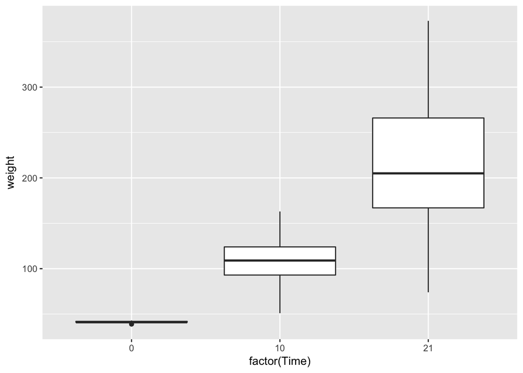

```r
ggplot(ChickWeight_subset, aes(factor(Time), weight)) +
  geom_boxplot(aes(group = factor(Time)), position = "dodge")
```

```r
# Interpretation: When the chick weights are compared from day 0 to day 21, their weights are increasing as they started to grow up.
```

3. How do chicks’ weights compare on different diets? Use facetting and side-by-side boxplots of the previous subset.

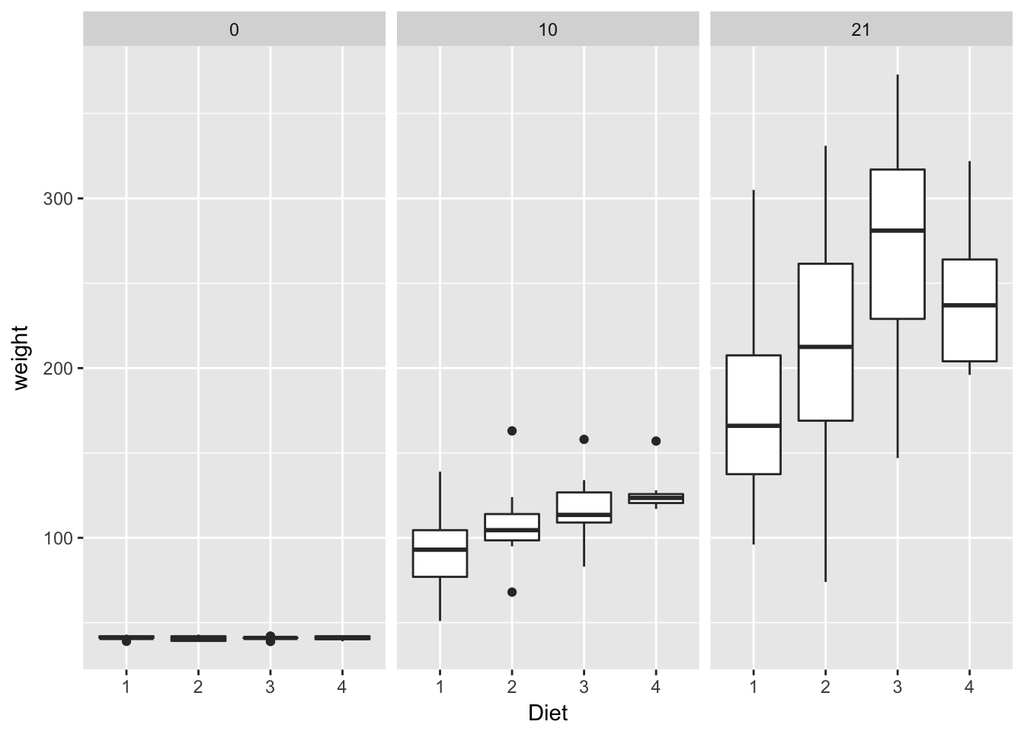

```r
ggplot(ChickWeight_subset, aes(Diet, weight)) +
  facet_wrap(~Time) +
  geom_boxplot(position = "dodge")
```

```r
# Interpretation: In day 0, none of the diet types have an impact on chick weights. The impacts of diet types can be seen clearly on day 10 and 21. When days 10 and 21 are compared, the chicks which are on diet 3 and 4 are getting bigger than the chicks who are on diet 1 and 2.
```

4. How many chicks survive to day 21 on each of the diets? Use facetted barcharts for an answer.

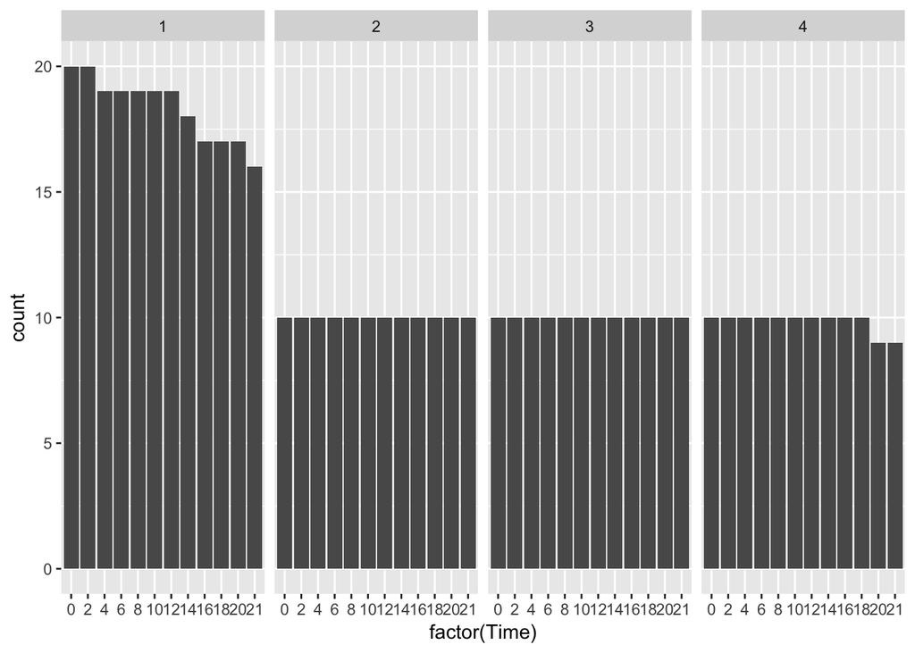

```r
ggplot(ChickWeight, aes(factor(Time))) + geom_bar() + facet_grid(~Diet)
```

```r
nrow(ChickWeight[which(ChickWeight$Time == 21 & ChickWeight$Diet == 1),])
```

```
## [1] 16
```

```r
nrow(ChickWeight[which(ChickWeight$Time == 21 & ChickWeight$Diet == 2),])
```

```
## [1] 10
```

```r
nrow(ChickWeight[which(ChickWeight$Time == 21 & ChickWeight$Diet == 3),])
```

```
## [1] 10
```

```r
nrow(ChickWeight[which(ChickWeight$Time == 21 & ChickWeight$Diet == 4),])
```

```
## [1] 9
```

5. Focus on chicks 10, 25, 35, and 45. Introduce a separate dataset for each of the chicks. For each of them, determine the minimum weight. Introduce a variable `rel.gain` into each dataset that measures the relative gain in weight (weight gain divided by minimum weight). Combine the four data sets into one (use `rbind`). Plot lines to show weight gains over time for each of the chicks. Color by Diet. Interpret the result.

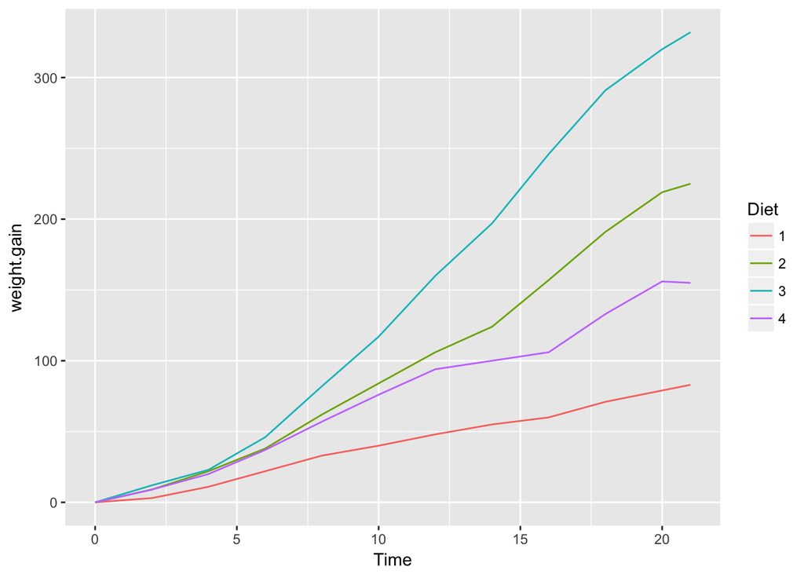

```r
Chicks_10 <- filter(ChickWeight, ChickWeight$Chick == 10)
a <- min(Chicks_10$weight)
Chicks_10$rel.gain <- (Chicks_10$weight-a)/a
Chicks_10$weight.gain <- (Chicks_10$weight-a)

Chicks_25 <- filter(ChickWeight, ChickWeight$Chick == 25)
b <- min(Chicks_25$weight)
Chicks_25$rel.gain <- (Chicks_25$weight-b)/b
Chicks_25$weight.gain <- (Chicks_25$weight-b)

Chicks_35 <- filter(ChickWeight, ChickWeight$Chick == 35)
c <- min(Chicks_35$weight)
Chicks_35$rel.gain <- (Chicks_35$weight - c)/c
Chicks_35$weight.gain <- (Chicks_35$weight - c)

Chicks_45 <- filter(ChickWeight, ChickWeight$Chick == 45)
d<- min(Chicks_45$weight)
Chicks_45$rel.gain <- (Chicks_45$weight - d)/d
Chicks_45$weight.gain <- (Chicks_45$weight - d)

Chicks <- rbind(Chicks_10, Chicks_25, Chicks_35, Chicks_45)

ggplot(Chicks, aes(Time, weight.gain)) + geom_line(aes(color = Diet))
```

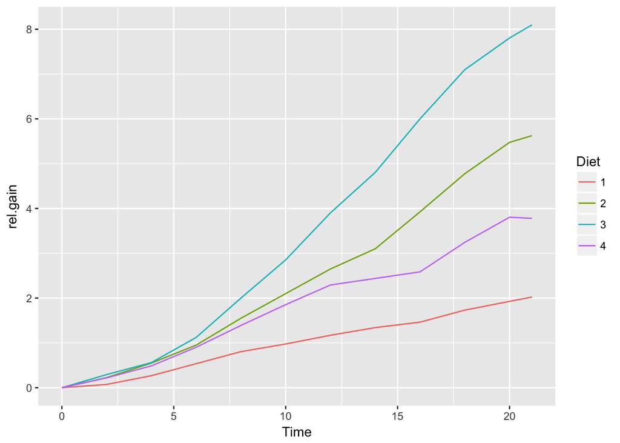

```r
ggplot(Chicks, aes(Time, rel.gain)) + geom_line(aes(color = Diet))
```

```r
# Interpretation: As seen in both plots, the order of effective diet is diet 3 > diet 2 > diet 4 > diet 1. That means diet 3 is the best diet to gain more weight for the chicks. However, it can be also foreseen that diet 4 may stop helping chicks to gain weight after day 21.
```